# STA6856 Time Series

Assignment 2

Author

Hector Gavilanes

Published

October 10, 2023

# Instructions:

**Submitting the same exact answer will lead to failing the assignment.**

## Problem A

Let $Z_t$ be a sequence of independent normal random variables, each with mean 0 and variance $\sigma^2$, and let $a$, $b$, and $c$ be constants. Which, if any, of the following processes are stationary? for each stationary process specify the mean, autocovariance, and autcorrelations functions.

1. $X_t = a+ bZ_t + cZ_{t-2}$
2. $X_t = a+ bZ_0$

## Problem B

Use the following time series:

- `airpass{itsmr}`: Number of international airline passengers, 1949 to 1960.
- `lake{itsmr}`: Level of Lake Huron, 1875 to 1972.

And perform the following:

1. Plot and examine the time series and its ACF.
2. Estimate the Trend and/or Season being considered using Moving Average Smoothing and Regression, if applicable
3. Plot both trend estimates and the original series in one figure.
4. Test the hypothesis whether or not the the residuals data are IID.
5. State your conclusions whether or not further analysis should be pursued. Why?
6. Use the differencing operator to eliminate the Trend/Season components and redo steps 4 and 5.

```r
# Load packages
library(itsmr)
library(tidyverse)
library(tsibble)
library(feasts)
```

# Airpass

```r
#Plot and examine the time series and its ACF.
is.ts(airpass)
```

```
[1] FALSE
```

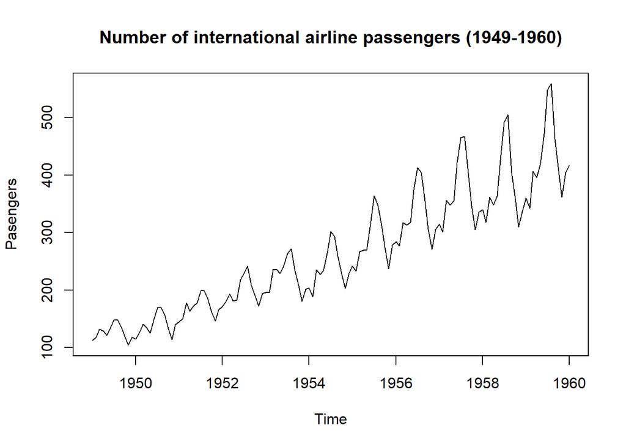

```r
air_ts = ts(airpass, start = c(1949, 1), end = c(1960, 1), frequency = 12)
plot.ts(air_ts, main="Number of international airline passengers (1949-1960)", ylab="Pasengers")
```

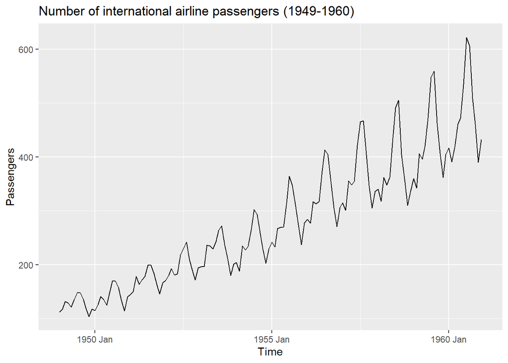

```r
# tsibble format
air_tb = airpass %>%
  as_tibble() %>%
  mutate(idx = seq(yearmonth("1949 Jan"),yearmonth("1960 Dec"),1)) %>%
  as_tsibble(index=idx)

# autoplot
air_tb %>%
  autoplot(value) +
  labs(x= "Time", y= "Passengers",
       title="Number of international airline passengers (1949-1960)")
```

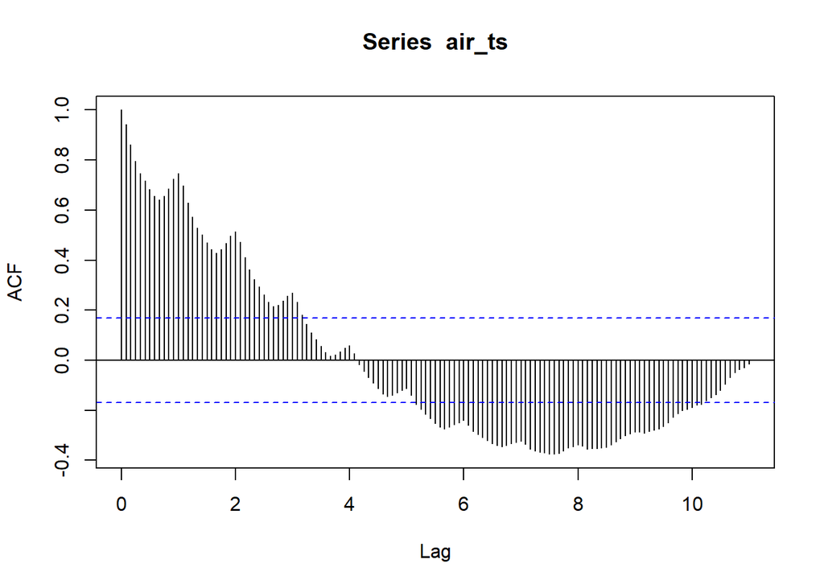

```r
# ACF
acf(air_ts, lag.max = 144)
```

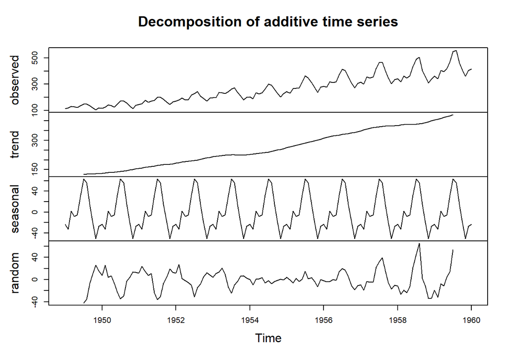

```r
#Estimate the Trend and/or Season being considered using Moving Average Smoothing and Regression, if applicable
air_decompose = decompose(air_ts)
plot(air_decompose)
```

## Trend Estimation: Smoothing Moving Average

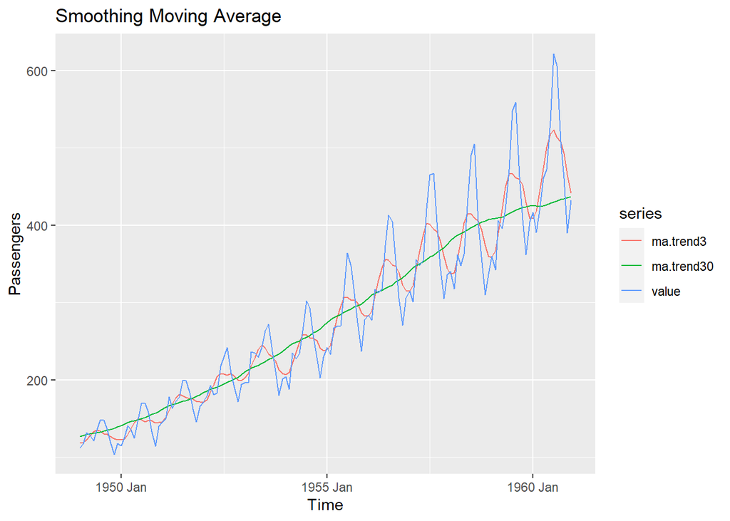

```r
air_tb %>%
  mutate(ma.trend3 = smooth.ma(value, 3),
         ma.trend30 = smooth.ma(value, 30)) %>%
  pivot_longer(cols=-idx,
               names_to = "series",
               values_to = "values") %>%
  group_by(series) %>%
  autoplot(values)+
  labs(y="Passengers", x="Time", title = "Smoothing Moving Average")
```

## Trend Estimation: Regression

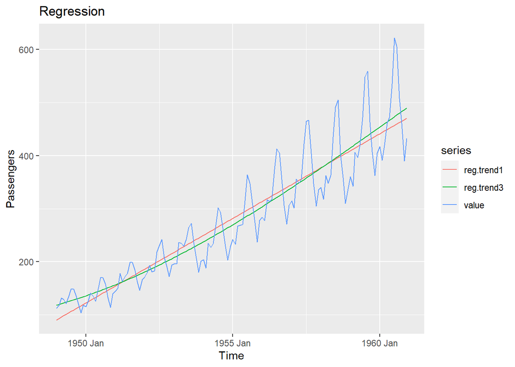

```r
air_tb %>%
  mutate(reg.trend1 = trend(value, 1),# 1 means polynmial of degree 1
         reg.trend3 = trend(value, 3)) %>%
  pivot_longer(cols=-idx,
               names_to = "series",
               values_to = "values") %>%
  group_by(series) %>%
  autoplot(values)+
  labs(y="Passengers", x="Time", title = "Regression")
```

## Seasonality

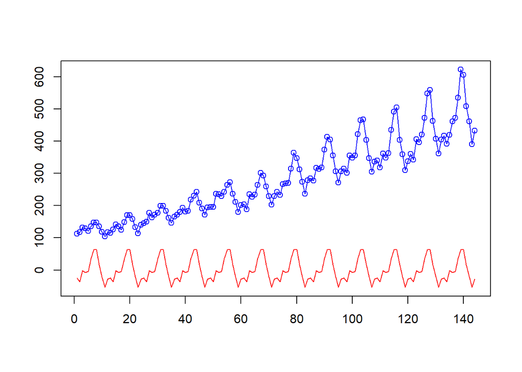

```r
estimate.season = season(air_tb$value, d=12)
plotc(air_tb$value, estimate.season)
```

## IID Hypothesis Test

```
Null hypothesis: Residuals are iid noise.
Test                        Distribution Statistic   p-value
Ljung-Box Q                Q ~ chisq(20)   1799.36         0 *
McLeod-Li Q                Q ~ chisq(20)   1623.09         0 *
Turning points T     (T-94.7)/5 ~ N(0,1)        58         0 *
Diff signs S       (S-71.5)/3.5 ~ N(0,1)        82    0.0025 *
Rank P           (P-5148)/289.5 ~ N(0,1)      9728         0 *
```

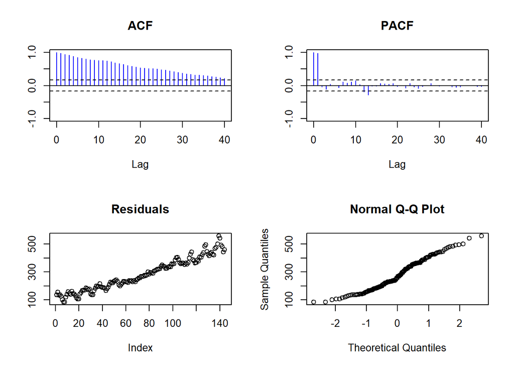

```r
#Test the hypothesis whether or not the the residuals data are IID.
r = air_tb$value - estimate.season
test(r)
```

```
Null hypothesis: Residuals are iid noise.
Test                        Distribution Statistic   p-value
Ljung-Box Q                Q ~ chisq(20)    404.13         0 *
McLeod-Li Q                Q ~ chisq(20)      92.7         0 *
Turning points T     (T-94.7)/5 ~ N(0,1)        68         0 *
Diff signs S       (S-71.5)/3.5 ~ N(0,1)        66    0.1136
Rank P           (P-5148)/289.5 ~ N(0,1)      4848       0.3
```

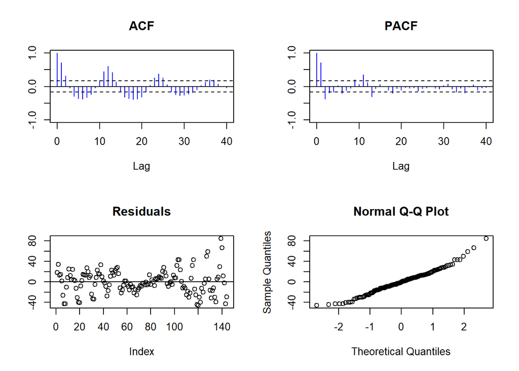

```r
# Resid() function to find residuals
data.model = c("season", 12, "trend", 3)
R = Resid(air_tb$value, data.model)
test(R)
```

```
Null hypothesis: Residuals are iid noise.
Test                        Distribution Statistic   p-value
Ljung-Box Q                Q ~ chisq(20)    602.74         0 *
McLeod-Li Q                Q ~ chisq(20)    175.11         0 *
Turning points T     (T-94.7)/5 ~ N(0,1)        64         0 *
Diff signs S       (S-71.5)/3.5 ~ N(0,1)        73    0.6661
Rank P           (P-5148)/289.5 ~ N(0,1)      4681    0.1067
```

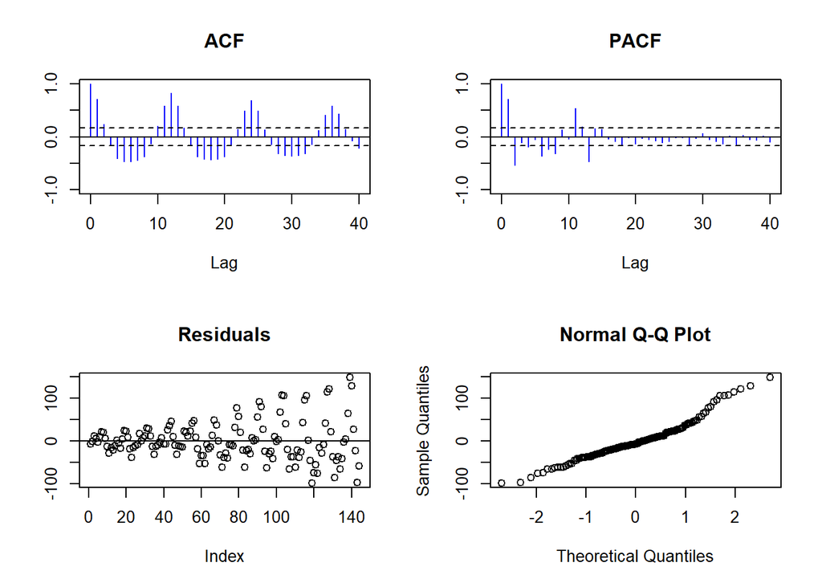

```r
data.model.s = c("trend",3)
R.s = Resid(air_tb$value, data.model.s)
# IDD test
test(R.s)
```

```
Null hypothesis: Residuals are iid noise.
Test                        Distribution Statistic   p-value
Ljung-Box Q                Q ~ chisq(20)    412.43         0 *
McLeod-Li Q                Q ~ chisq(20)     41.29    0.0034 *
Turning points T     (T-94.7)/5 ~ N(0,1)        85    0.0545
Diff signs S       (S-71.5)/3.5 ~ N(0,1)        68     0.314
Rank P           (P-5148)/289.5 ~ N(0,1)      5187    0.8928
```

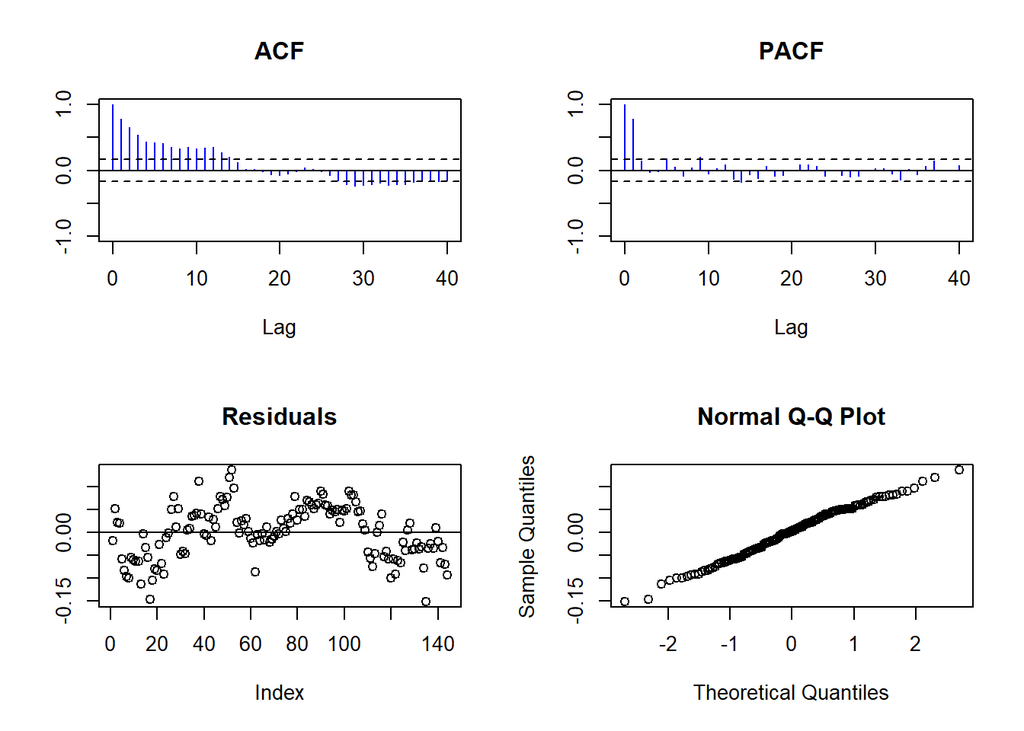

```r
data.model.log = c("log", "season", 12, "trend",1)
R.log = Resid(air_tb$value, data.model.log)
# IDD test
test(R.log)
```

## Conclusion

After performing the IID hypothesis test, I can conclude the following:

Reject $H_0$ at $\alpha = 0.05$. There is sufficient evidence to suggest that the residuals are statistically significant. Thus, the residuals do not comply with the IID hypothesis.

## Differencing Operator to eliminate the Trend/Season components

The Airpass model:

$$X_t = m_t + s_t + Y_t$$

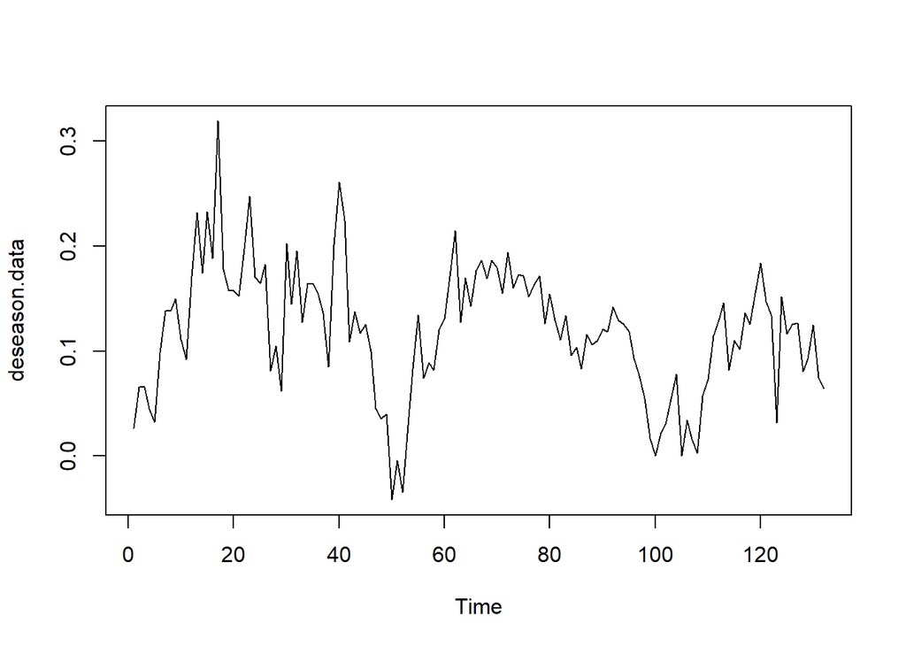

```r
deseason.data = diff(log(air_tb$value), lag = 12)
plot.ts(deseason.data)
```

```
Null hypothesis: Residuals are iid noise.
Test                        Distribution Statistic   p-value
Ljung-Box Q                Q ~ chisq(20)    190.61         0 *
McLeod-Li Q                Q ~ chisq(20)      90.8         0 *
Turning points T   (T-84.7)/4.8 ~ N(0,1)       100    0.0013 *
Diff signs S         (S-64)/3.3 ~ N(0,1)        65    0.7613
Rank P           (P-4128)/245.6 ~ N(0,1)      4180    0.8323
```

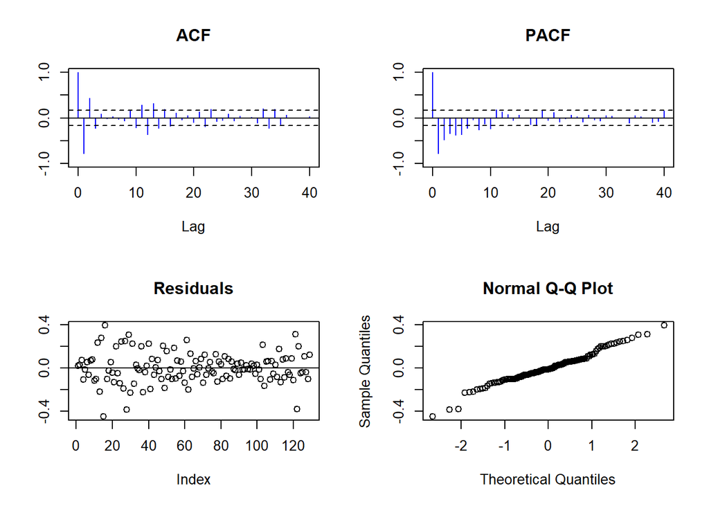

```r
# Eliminate Trend - estimate cubic trend
residual.cubic.data = diff(deseason.data, lag=1, differences = 3)
# IID test
test(residual.cubic.data)
```

## Final Conclusion

Reject the Null Hypothesis of IID; therefore, further analysis needs to be done.

# Lake

```r
#Plot and examine the time series and its ACF.
is.ts(lake)
```

```
[1] FALSE
```

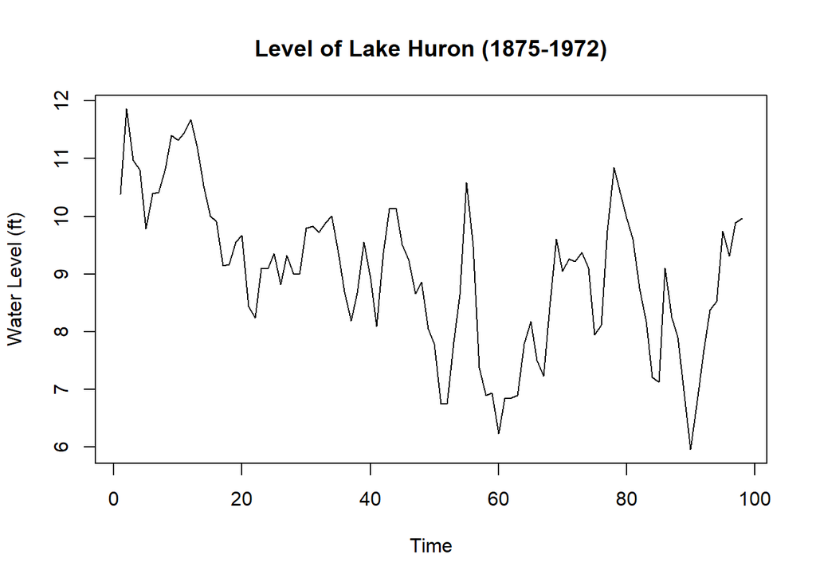

```r
plot.ts(lake, main="Level of Lake Huron (1875-1972)",
        ylab="Water Level (ft)")
```

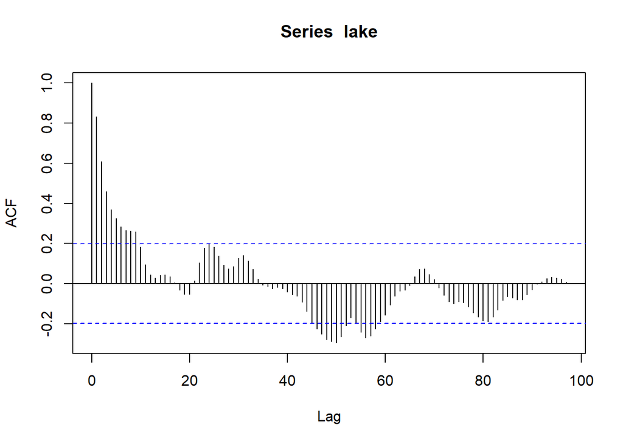

```r
# ACF
acf(lake, lag.max = 98)
```

```r
# tsibble format
lake_tb = tsibble(year=1875:1972,
                  index = year,
                  data= lake)
# change column names
colnames(lake_tb) <- c("year", "level")
```

There is no seasonality. Not noticeable variance change, and downward trend.

$$X_t = m_t + Y_t$$

## Trend Estimation: Moving Averages

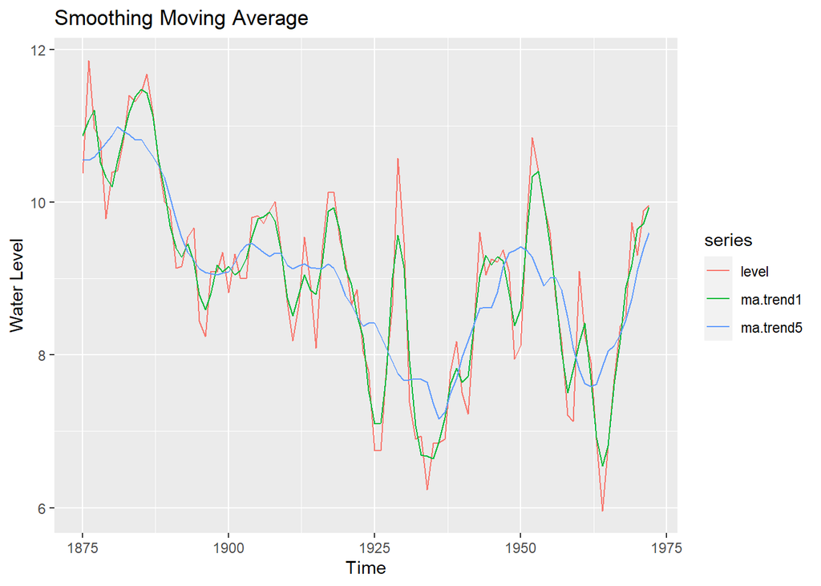

```r
#Estimate the Trend and/or Season being considered using Moving Average Smoothing and Regression, if applicable

lake_tb %>%
  mutate(ma.trend1 = smooth.ma(level, 1),
         ma.trend5 = smooth.ma(level, 5)) %>%
  pivot_longer(cols=-year,
               names_to = "series",
               values_to = "level") %>%
  group_by(series) %>%
  autoplot(level)+
  labs(y="Water Level", x="Time", title = "Smoothing Moving Average")
```

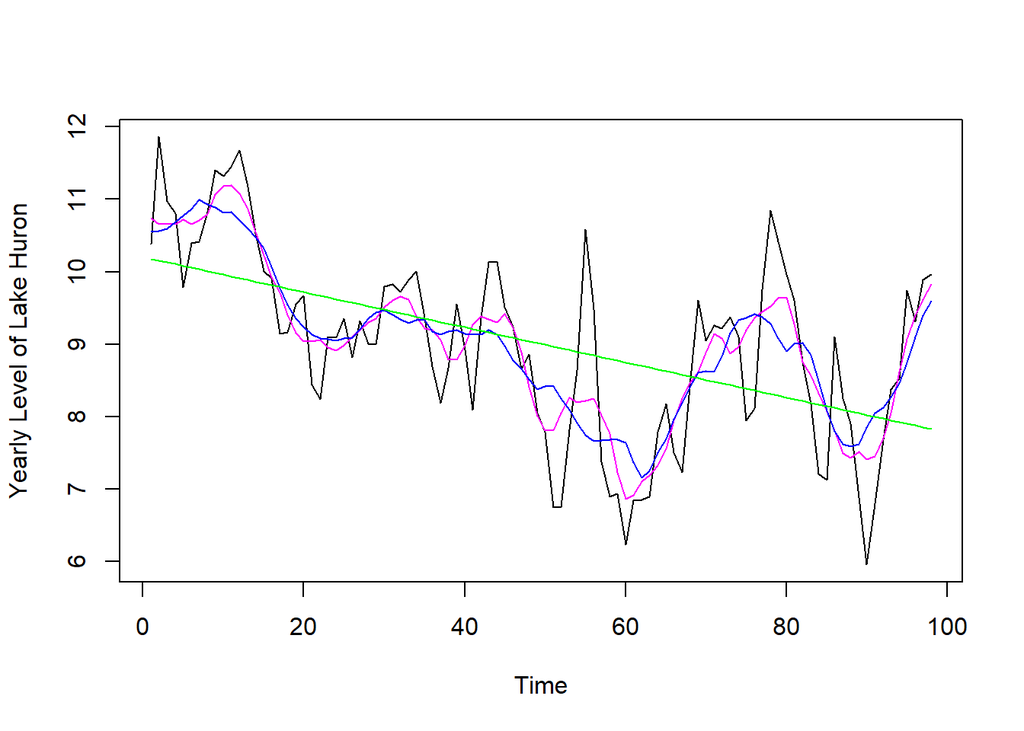

```r
# Estimate Trend
m = smooth.ma(lake, 3) #moving average filter
m2 = smooth.ma(lake, 5) #moving average filter
mreg = trend(lake, 1) #polynomial regression
plot(lake, type="l",
     ylab = "Yearly Level of Lake Huron",
     xlab = "Time")
lines(m, col="magenta")
lines(m2, col="blue")
lines(mreg, col="green")
```

## Trend Estimation: Regression

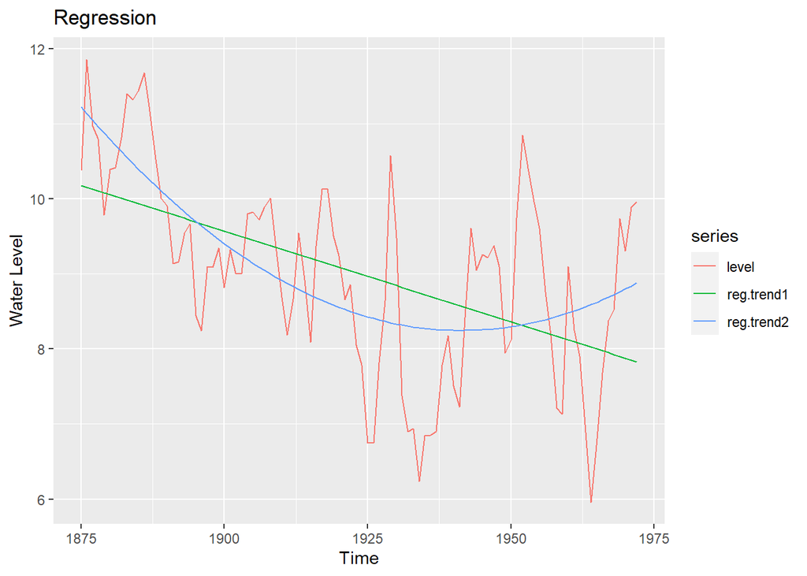

```r
lake_tb %>%
  mutate(reg.trend1 = trend(level, 1),
         reg.trend2 = trend(level, 2)) %>%
  pivot_longer(cols=-year,
               names_to = "series",
               values_to = "level") %>%
  group_by(series) %>%
  autoplot(level)+
  labs(y="Water Level", x="Time", title = "Regression")
```

Downward trend.

## Seasonality

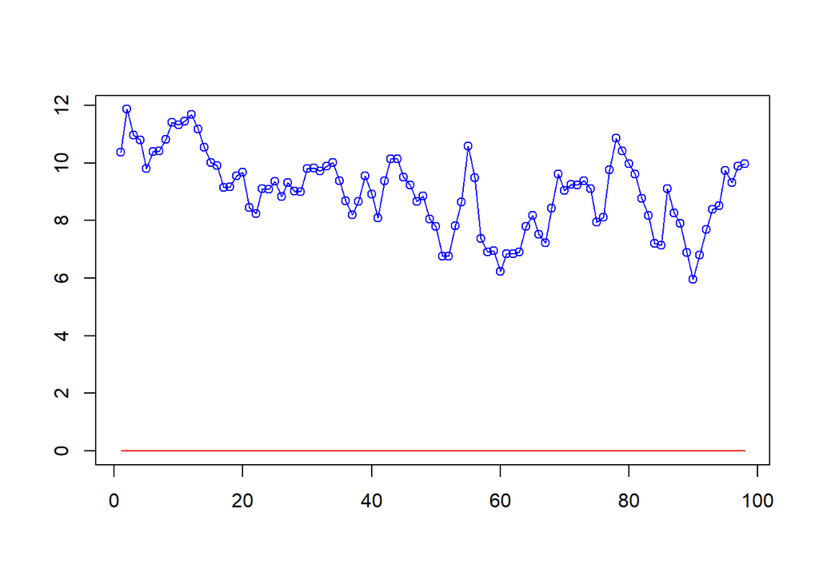

```r
estimate.season = season(lake_tb$level, d=1)
plotc(lake_tb$level, estimate.season)
```

No seasonality

## IID Hypothesis Test

```
Null hypothesis: Residuals are iid noise.
Test                        Distribution Statistic   p-value
Ljung-Box Q                Q ~ chisq(20)    138.67         0 *
McLeod-Li Q                Q ~ chisq(20)     56.45         0 *
Turning points T     (T-64)/4.1 ~ N(0,1)        40         0 *
Diff signs S       (S-48.5)/2.9 ~ N(0,1)        50    0.6015
Rank P         (P-2376.5)/162.9 ~ N(0,1)      2406    0.8563
```

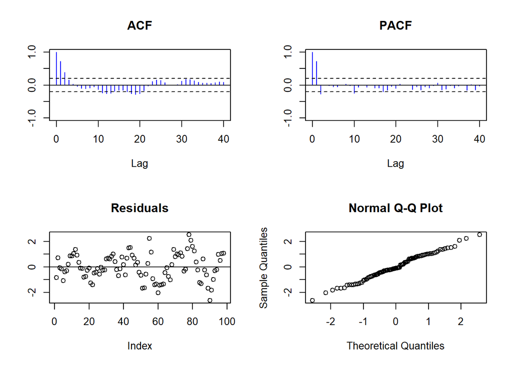

```r
# Alternative method
estimate.trend = trend(lake_tb$level, 2)
r_lake = lake_tb$level - estimate.trend
test(r_lake)
```

```
Null hypothesis: Residuals are iid noise.
Test                        Distribution Statistic   p-value
Ljung-Box Q                Q ~ chisq(20)    138.67         0 *
McLeod-Li Q                Q ~ chisq(20)     56.45         0 *
Turning points T     (T-64)/4.1 ~ N(0,1)        40         0 *
Diff signs S       (S-48.5)/2.9 ~ N(0,1)        50    0.6015
Rank P         (P-2376.5)/162.9 ~ N(0,1)      2406    0.8563
```

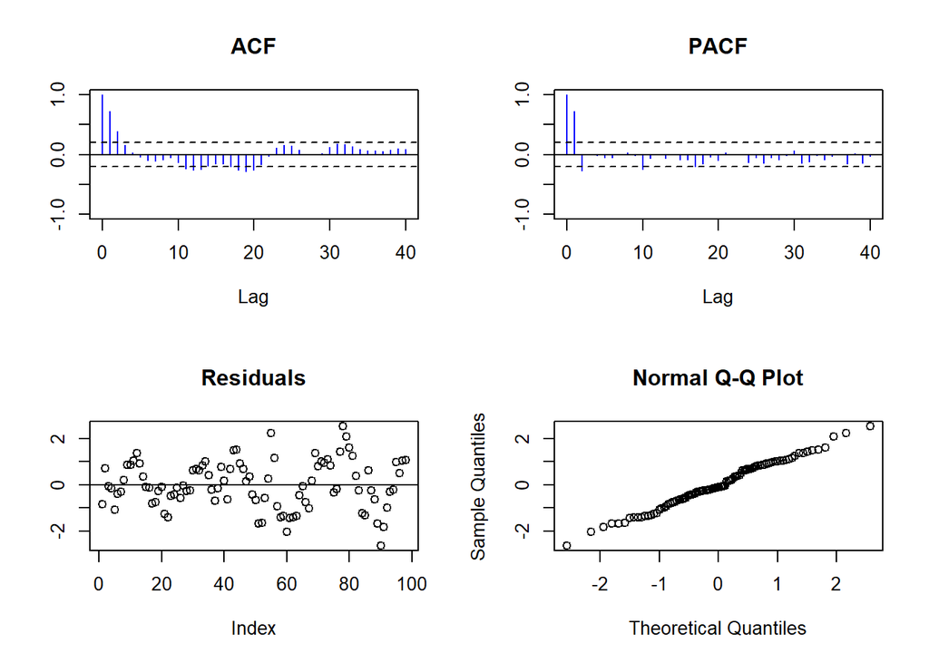

```r
# Resid() function to find residuals
data.model.lake = c("trend", 2)
R = Resid(lake_tb$level, data.model.lake)
test(R)
```

## Conclusion

After performing the IID hypothesis test, I can conclude the following:

Reject $H_0$ at $\alpha = 0.05$. There is sufficient evidence to suggest that the residuals are statistically significant. Thus, the residuals do not comply with the IID hypothesis.

## Differencing Operator to eliminate the Trend/Seasonality

The Lake model:

$$X_t = m_t + Y_t$$

By Elimination, we have the following:

$$y_t = \nabla^2 +Y_t$$

rewrite this as:

$$y_t = (1 - B)^2 X_t$$

```
Null hypothesis: Residuals are iid noise.
Test                        Distribution Statistic   p-value
Ljung-Box Q                Q ~ chisq(20)     24.12    0.2371
McLeod-Li Q                Q ~ chisq(20)     13.69    0.8459
Turning points T   (T-62.7)/4.1 ~ N(0,1)        63    0.9351
Diff signs S       (S-47.5)/2.8 ~ N(0,1)        49    0.5978
Rank P             (P-2280)/158 ~ N(0,1)      2303    0.8842
```

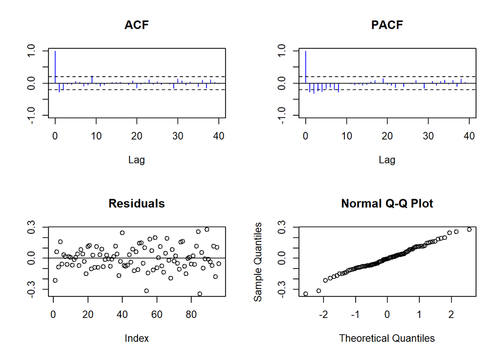

```r
# Eliminate Trend - estimate cubic trend
residual.squared.lake = diff(log(lake_tb$level), lag=1, differences = 2)
# IID test
test(residual.squared.lake)
```

```
Null hypothesis: Residuals are iid noise.
Test                        Distribution Statistic   p-value
Ljung-Box Q                Q ~ chisq(20)     25.24    0.1923
McLeod-Li Q                Q ~ chisq(20)     23.73    0.2545
Turning points T   (T-63.3)/4.1 ~ N(0,1)        63    0.9354
Diff signs S         (S-48)/2.9 ~ N(0,1)        48         1
Rank P           (P-2328)/160.4 ~ N(0,1)      2354    0.8713
```

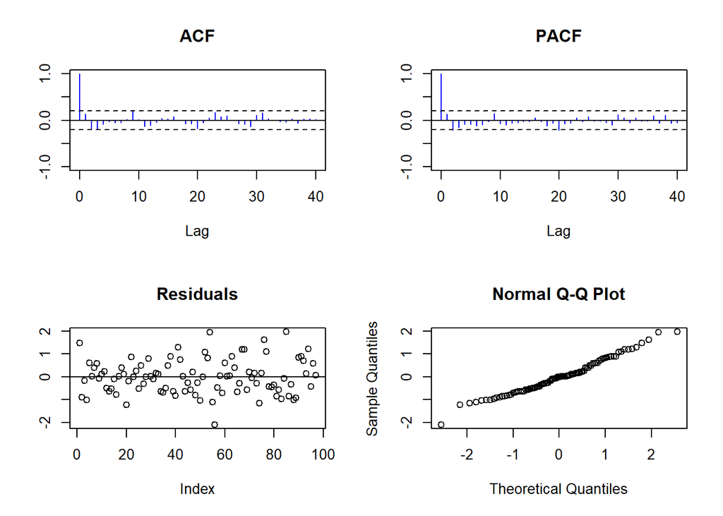

```r
# Better method
data.model.diff = c("diff", 1)
r.diff = Resid(lake, data.model.diff)
test(r.diff)
```

Failed to reject the IID Null Hypothesis at $\alpha = 0.05$ when using differencing operator. No further analysis is required.

## Fit ARMA(p,q) model to ‘lake’ data

```r
armaauto = autofit(R) #AR(p)=2 as best model from phi
arma21 = arma(R, p=2, q=1) #ARMA(2,1)
ar1 = arma(R, p=1, q=0)#ARMA(1,0) = AR(1)
```

```
Null hypothesis: Residuals are iid noise.
Test                        Distribution Statistic   p-value
Ljung-Box Q                Q ~ chisq(20)     23.23    0.2778
McLeod-Li Q                Q ~ chisq(20)     12.04    0.9145
Turning points T   (T-63.3)/4.1 ~ N(0,1)        64    0.8713
Diff signs S         (S-48)/2.9 ~ N(0,1)        48         1
Rank P           (P-2328)/160.4 ~ N(0,1)      2356    0.8614
```

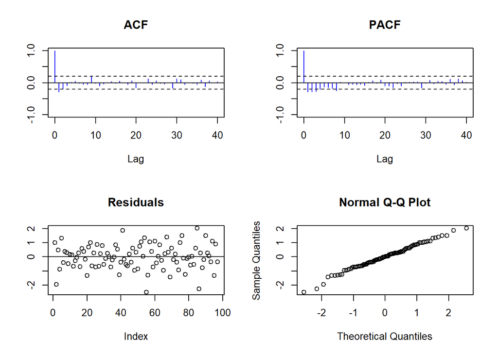

```r
#IID test residual of the model
# Specify phi, theta, sigma
arma.model = specify(ar = ar1$phi,
                    ma = ar1$theta,
                    sigma2 = ar1$sigma2)
arma.R = Resid(x=lake, M=data.model.diff, a=arma.model)
test(arma.R)
```